# SCEM Assignment 9

Max Kirwan

01/12/2021

```r
library(tidyverse)
```

## 1. Basic concepts in classification

Below I shall explain some basic concepts:

- **A classification rule** - This is a rule $\phi:\mathcal{X}\to\mathcal{Y}$ which takes in a feature vector $X\in\mathcal{X}$ and returns a categorical variable $\phi(\mathcal{X})\in\mathcal{Y}$.
- **A learning algorithm** - This is an algorithm which takes in a training data set of feature vector and categorical variable pairs and learns how these are related, so that it can then predict the categorical outputs of unseen feature vectors.
- **Training data** - This is data, in the form of feature vector and categorical variable pairs, which is used to train the learning algorithm.
- **Feature vector** - This is a d-dimensional vector $X=(X_1,...,X_d)\in\mathcal{X}$, which represents the d recorded features. For example, the bill length, flipper length and weight of a penguin $X=(x_b,x_f,x_w)\in\mathcal{X}=\mathbb{R}^d$.
- **Label** - A label is a categorial variable $\phi(\mathcal{X})\in\mathcal{Y}$. Using the penguin example, this might be $1$ if the penguin species is Gentoo and $0$ if the species is Adelie.
- **Test error** - The test error is the average number of errors in the test data. An error is when the categorical variable assigned to a feature vector by the classification rule does not match to its actual categorical variable.
- **Train error** - The train error is the average number of errors in the train data.
- **The train test split** - This is the way we randomly divide our data set into a training and test data set. A common practice is to use an 80:20 split.
- **Linear classifier** - A linear classifier $\phi:\mathcal{X}\to\{0,1\}$ seperates the data by cutting the feature space in two with a linear hyper-plane. This only works if the data is linearly seperable.

## 2. The train test split

```r
library(Stat2Data)
data("Hawks")
hawks_total <- Hawks %>% select(Weight,Wing,Tail,Hallux,Species) %>% filter(Species %in% c("RT","SS")) %>% mutate(Species=as.numeric(Species=="SS")) %>% drop_na()

# We want a random 60:40 split
set.seed(23)
sample <- sample.int(nrow(hawks_total),floor(nrow(hawks_total)*0.6))
hawks_train <- hawks_total[sample,]
hawks_test <- hawks_total[-sample,]
hawks_train_x <- hawks_train %>% select(-Species)
hawks_train_y <- hawks_train %>% select(Species)
hawks_test_x <- hawks_test %>% select(-Species)
hawks_test_y <- hawks_test %>% select(Species)

# Choosing a deterministic value for phi which minimises the training error
hawks_train_y %>% count(Species)
```

```
##   Species   n
## 1       0 345
## 2       1 149
```

```r
phi <- 0
train_error <- mean(pull(abs(phi-hawks_train_y),Species))
test_error <- mean(pull(abs(phi-hawks_test_y),Species))

# We can see that there is a roughly 70:30 split between the two species of hawks
print(c(train_error,test_error))
```

```
## [1] 0.3016194 0.3212121
```

## 3. Linear discriminant analysis

We model $Y\in\{0,1\}$ and $X\in\mathbb{R}^4$ as a Bernoulli followed by a Gaussian:

$Y\sim \mathcal{B}(q)$ and
$$X \sim \mathcal{N}(\mu_0,\Sigma) \text{ if }Y=0 \\ X \sim \mathcal{N}(\mu_1,\Sigma) \text{ if }Y=1$$

```r
lda_model <- MASS::lda(Species~.,data=hawks_train)
lda_train_predicted <- predict(lda_model,hawks_train_x)$class %>% as.character() %>% as.numeric()
lda_train_error <- mean(abs(lda_train_predicted-pull(hawks_train_y,Species)))
lda_test_predicted <- predict(lda_model,hawks_test_x)$class %>% as.character() %>% as.numeric()
lda_test_error <- mean(abs(lda_test_predicted-pull(hawks_test_y,Species)))
c(lda_train_error,lda_test_error)
```

```
## [1] 0.010121457 0.003030303
```

## 4. Logistic regression

Logistic regression is a probabilistic method for learning a linear classifier $\phi(x)=\mathbf{1}\{wx^\top+w_0\ge0\}$.  
We only need to model $\mathbb{P}(Y=y|X=x)$.  
We use the sigmoid function $S(z)=\frac{1}{1+e^{-z}}$.

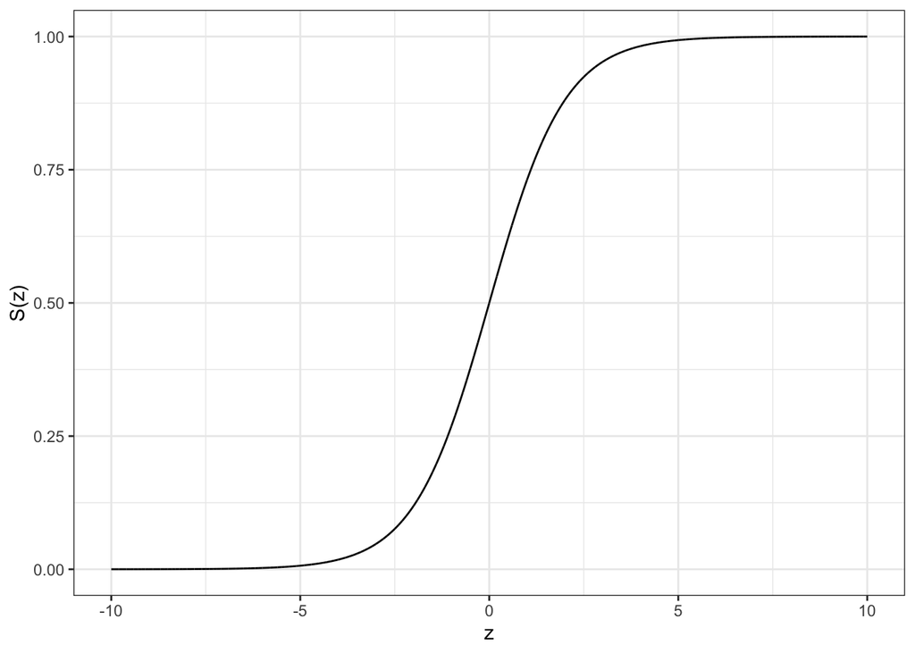

```r
# Generating a plot to display the sigmoid function
sigmoid_func <- function(z){1/(1+exp(-z))}
sigmoid_plot_df <- data.frame(z=seq(-10,10,0.001)) %>%
  mutate(sigmoid_z=map_dbl(.x=z,.f=~sigmoid_func(.x)))
ggplot(sigmoid_plot_df,aes(x=z,y=sigmoid_z,)) + geom_line() + theme_bw() + ylab("S(z)")
```

```r
library(glmnet)
# Training a logistic regression model
log_reg_model <- glmnet(x=hawks_train_x%>%as.matrix(),y=pull(hawks_train_y,Species),family="binomial",alpha=0,lambda=0)
log_reg_train_predicted <- predict(log_reg_model,hawks_train_x%>%as.matrix(),type="class")%>%as.numeric()
log_reg_train_error <- mean(abs(pull(hawks_train_y,Species)-log_reg_train_predicted))
log_reg_test_predicted <- predict(log_reg_model,hawks_test_x%>%as.matrix(),type="class")%>%as.numeric()
log_reg_test_error <- mean(abs(pull(hawks_test_y,Species)-log_reg_test_predicted))
c(log_reg_train_error,log_reg_test_error)
```

```
## [1] 0.004048583 0.009090909
```